# AI in Pedagogical Design and Delivery

[← Back](https://michaelborck-presentations.github.io/ai-in-pedagogical-design-and-delivery/index.html)

# AI in Pedagogical Design and Delivery

Author

Michael Borck

Published

November 19, 2025

# Welcome & The AI Landscape

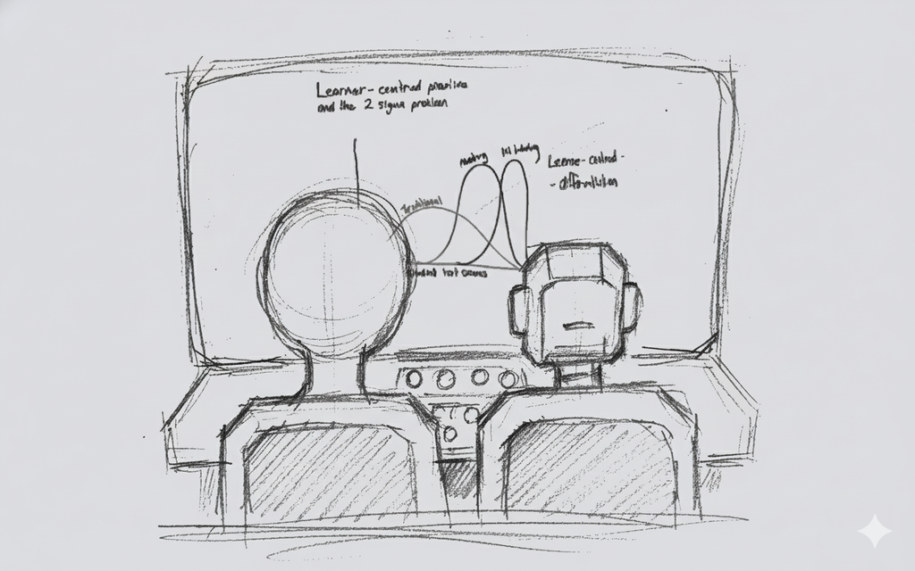

Drafting and ideation for these materials were supported by generative AI tools, Python scripts, Quarto, and standard image editors under human oversight. All content has been reviewed, edited and verified by the author.

“Two standard deviations.”

[pause 2–3 seconds, make eye contact]

That’s the gap Benjamin Bloom reported in the 1980s between students in a typical classroom and students who received one‑to‑one human tutoring – enough to turn an average student into a top performer.

Fast‑forward forty years. Sal Khan – the Khan Academy guy – stands on a TED stage and says: with AI tutors and AI teaching assistants, we might finally be able to get something like that 2‑sigma effect at scale. A personal tutor for every student, and an AI assistant for every teacher.

Whether that makes you excited or slightly ill, it raises a very practical question for us here at Curtin: If tools like this are going to sit in our students’ hands – and in our own enterprise Copilot environment – how do we design teaching, assessment and support so that we get the upside without losing what actually matters?

And how does that sit alongside Assessment 2030, academic integrity, and the reality that students can now summon a ‘tutor’ at 2am from their phone?”

“Even if you’re not teaching every day, there’s a similar promise in our research and professional roles – a kind of co‑pilot for the boring parts of our jobs – drafting, summarising, chasing patterns – so we can spend more time on work that needs human judgement and relationships.”

“That’s what this session is about. We’re going to:

– Experiment with using AI to automate some of the tedious work, – Practise how to design prompts and critique AI outputs, and – Stress‑test our own assessments and practices in the spirit of Assessment 2030 – not to ban AI, but to redesign so that student judgement, process, and human skills remain irreplaceable.”

“We also know from recent work that if we lean too hard on these tools, we risk cognitive offloading, students feeling less connected, and making cheating easier if our assessments are too automatable. So we’ll spend as much time on how to critique and design around AI as we do on the shiny productivity side.”

# What We’ll Do Today

- Set the scene: AI, Assessment 2030, and your context
- Try out 5 hands‑on activities:
  - Automate some of the tedious work
  - Design better prompts
  - Critique AI outputs with a simple framework
  - Use AI in a multi‑step workflow to probe or redesign a task
  - Make one small commitment about safe AI use
- Wrap up with key takeaways and next steps

This slide gives you a roadmap for the session. We start with a short overview linking AI to Assessment 2030, then move into five hands‑on activities: using AI to automate some tedious work, designing better prompts, critiquing AI outputs, testing an assessment or complex task, and making one small commitment about safe use.

The focus is practical and beginner‑friendly: you will work with your own materials where possible, ask questions as you go, and leave with ideas you can try in your own context. For a short written overview of the workshop structure, see ‘What to Expect: AI in Pedagogical Design & Delivery Workshop’ and the individual activity handouts (Activities 1–5).

# Intelligent Tutoring Systems (ITS)

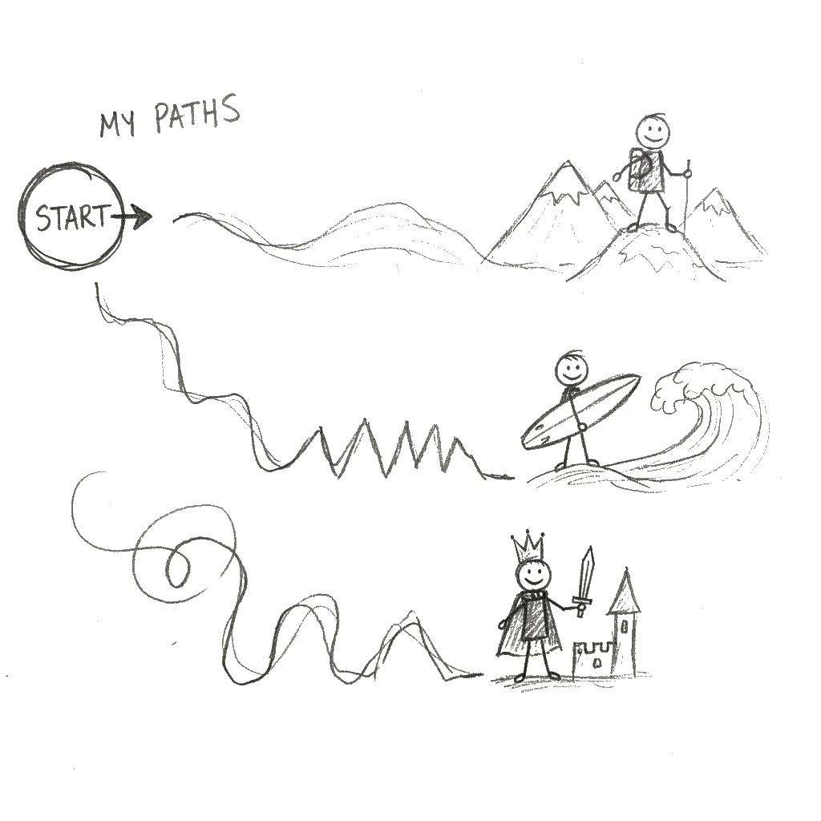

So the shape of the next two hours is roughly this: a bit of context to connect AI to Assessment 2030, then five very practical activities – automate, prompt, critique, multi‑step workflows, and safe use and then a short wrap‑up.

It’s designed to be mostly hands‑on and beginner‑friendly, with space for questions and discussion as we go.

For Activity 4 we have two possible paths, depending on how much Assessment 2030 you’ve already had today:we can either probe one of our assessments with AI and discuss redesign, or we can use a multi‑step AI workflow to tackle one of those ‘impossible’ teaching or design problems. We’ll pick on the day based on the room.

“Just as we’ll explore today, these slides and the website were developed with AI support – for drafting, structuring and idea generation – but always with human oversight, editing and verification. So this session is very much about walking the talk as well as talking about it.”

# The Architect (Pedagogical Design)

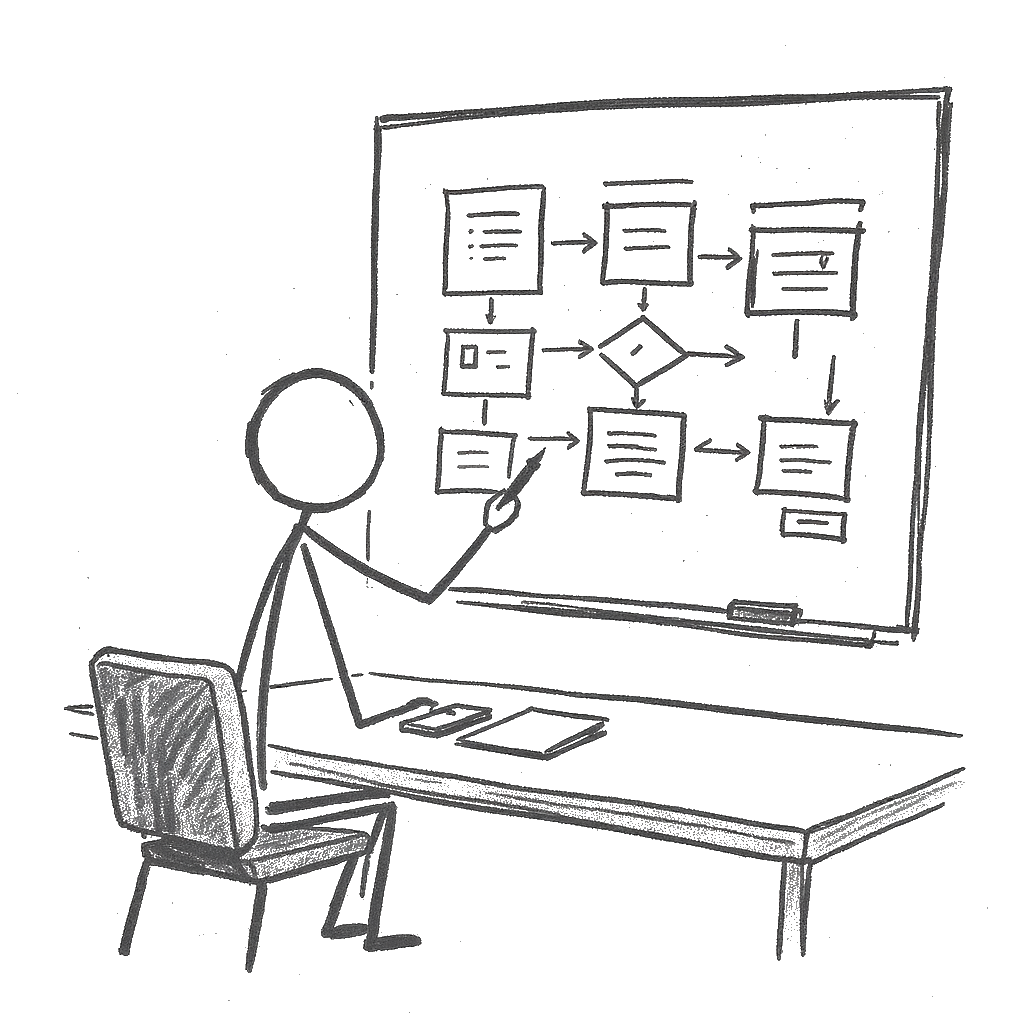

This slide is about the “architect” side of teaching: how courses and learning activities are designed. AI can now help with many of the slow, manual tasks (like drafting outlines, example assessments or slides), which pushes pedagogical designers to focus more on big‑picture questions.

In practice, the designer becomes more of a strategic architect: setting learning goals, shaping flexible pathways, and planning how human connection and emotion will be supported, rather than just producing content. For more detail and the full ship analogy, see the ‘Impact on Pedagogical Design (The Architect)’ section in ‘AI in Pedagogical Design and Delivery’.

# The Practitioner (Pedagogical Delivery)

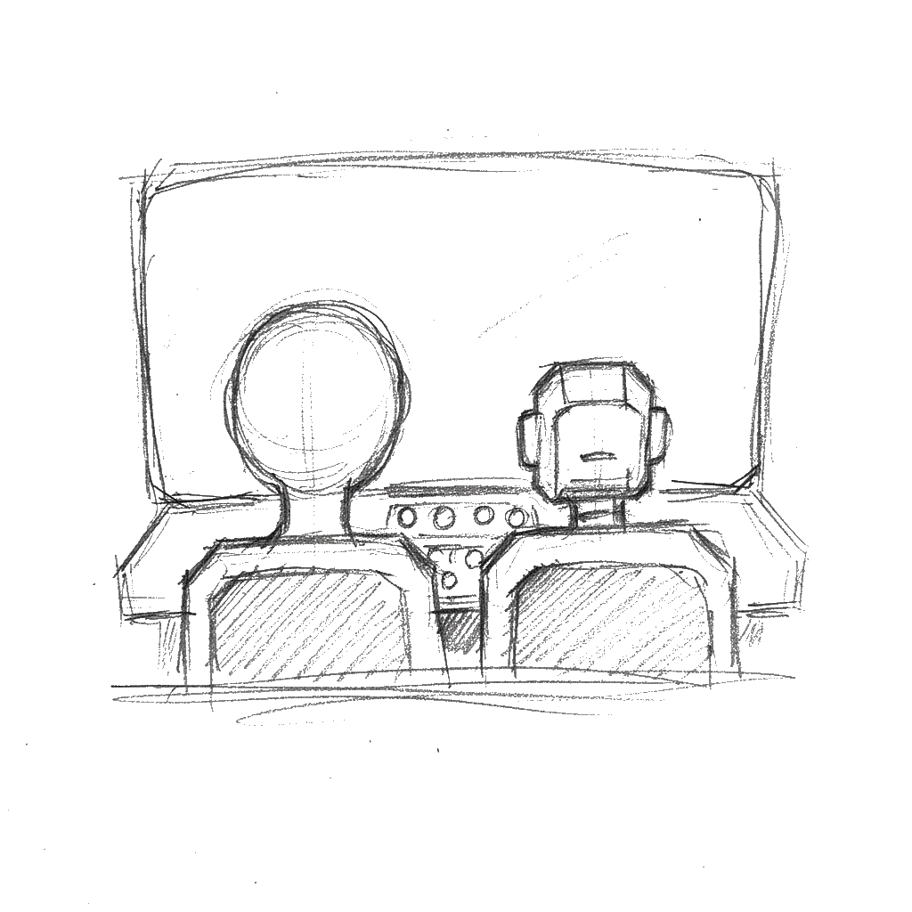

Here the focus shifts from design to day‑to‑day teaching (“the practitioner”). AI tools can help deliver content, monitor participation, and surface patterns in student work, so that teachers can spend more time on targeted support, feedback and relationship‑building.

You can think of AI as a co‑pilot: it handles routine monitoring and some explanations, while the human teacher makes real‑time decisions, manages complexity, and responds to students as people. For a deeper explanation and examples, see the ‘Impact on Pedagogical Delivery (The Practitioner)’ section in ‘AI in Pedagogical Design and Delivery’.

# Challenges & Limitations

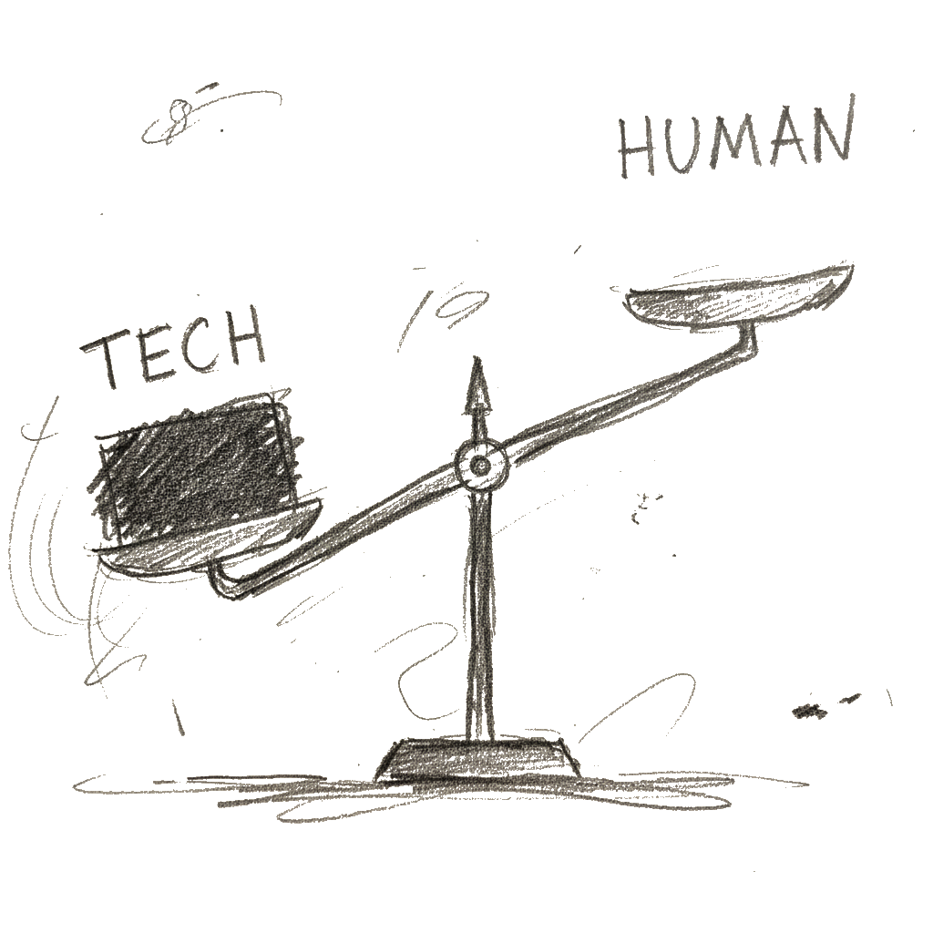

This slide highlights why AI in education is not just exciting but also risky. Over‑reliance on tools can weaken human connection, and data‑driven systems can amplify existing inequities or biases if they are not designed and monitored carefully.

Generative AI can also hallucinate, spread misinformation, and make some traditional assessments easier to game. Rather than banning AI, the workshop focuses on redesigning tasks, feedback and policies so that student thinking and judgement stay central—an idea captured in Assessment 2030. For more discussion of these tensions, see ‘Using AI in Education: Roles for Teaching & Research’ and the ‘Challenges & Limitations’ section in ‘AI in Pedagogical Design and Delivery’.

# The Evolving Role of the Educator

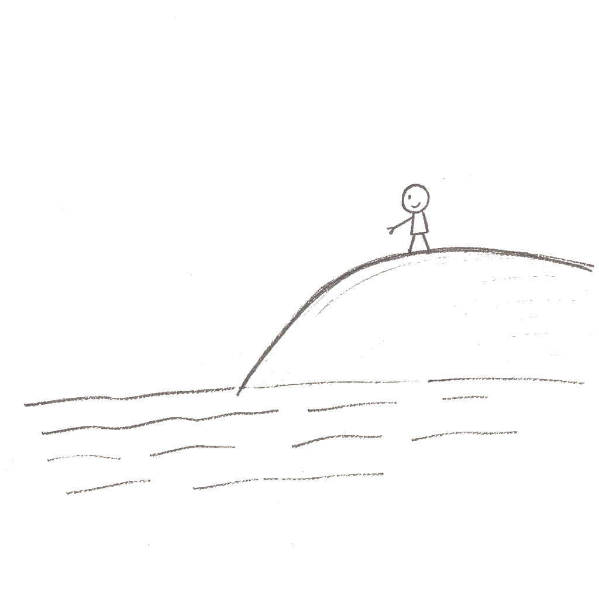

In the long term, AI pushes educators toward what only humans can do. As more routine tasks (like drafting, basic explanations and some grading support) become automatable, the value of empathy, mentoring, feedback, ethical judgement and creative design increases.

You can think of AI as a rising tide that covers low‑lying, repetitive tasks, leaving the “high ground” of human skills more visible. For a fuller argument and examples, see ‘The Evolving Human‑Centric Educator’ section in ‘AI in Pedagogical Design and Delivery’ and ‘Using AI in Education: Roles for Teaching & Research’.

# Activity 1: Automate the Tedious

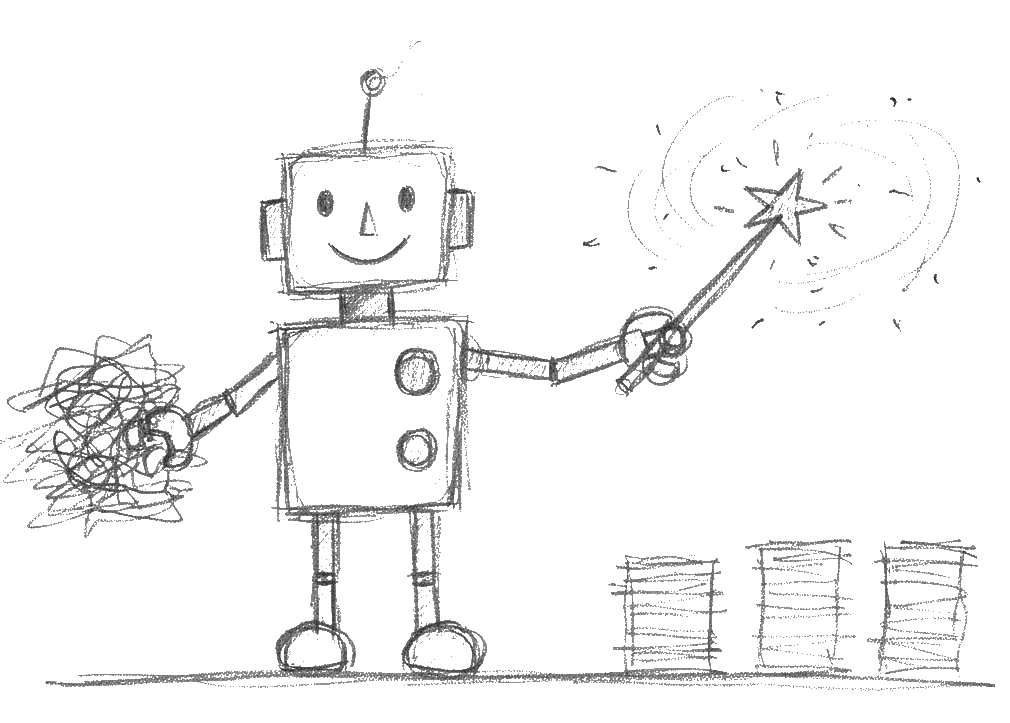

In Activity 1 you use AI as a summariser and re‑packager. You start from a real text (such as a reading excerpt, assignment brief or policy section), ask AI for a short, student‑friendly summary, then turn that summary into something useful: an LMS announcement, a two‑slide outline, or a short quiz.

The key idea is that AI can speed up routine drafting, but you still review and edit the output so it fits your unit, students and voice. For step‑by‑step prompts and variants for research and professional roles, see the handout ‘Activity 1 – Automate the Tedious’ and the ‘Quick Start Guide: AI in Education’.

# Activity 2: The Art of the Prompt

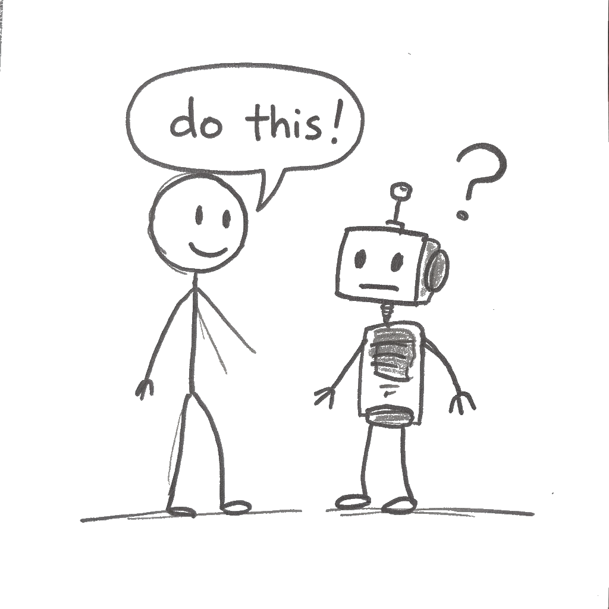

Activity 2 is about improving how you ask AI for help. You take a vague prompt you actually used, then rewrite it using a simple structure: context, role, action, format and tone/constraints. Running both prompts side‑by‑side shows how much clearer, more relevant and more usable the structured output is.

This activity links directly to the C.R.A.F.T. approach to prompting. For worked examples and extra patterns (including feedback helpers and redesign prompts), see ‘Activity 2 – The Art of the Prompt’ and the ‘C.R.A.F.T. Prompting Framework’.

# Activity 3: Your 5-Step Critique Framework

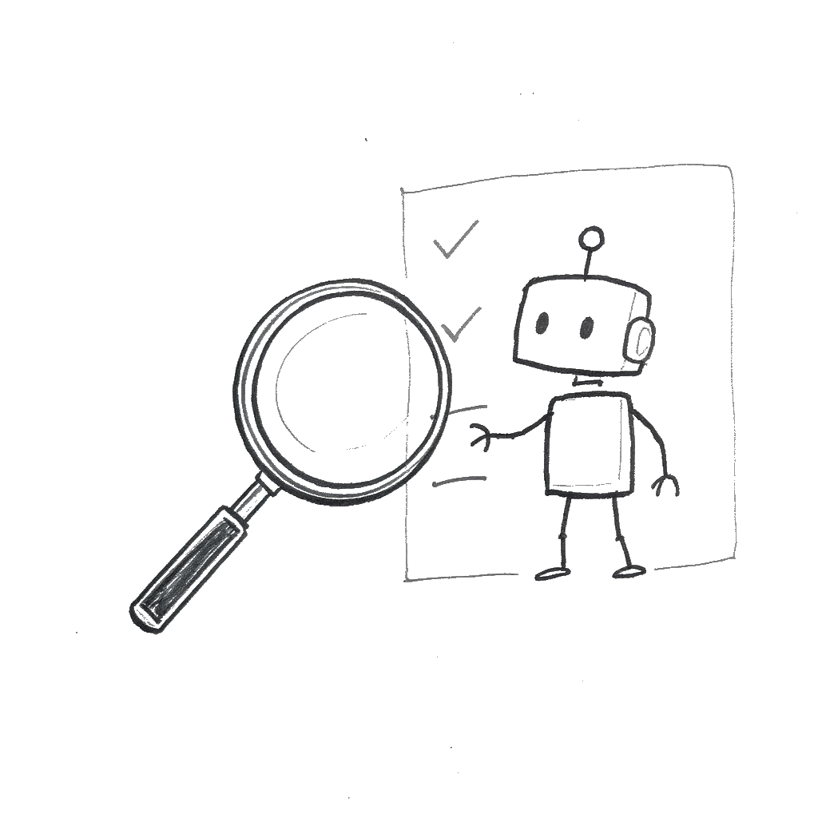

In Activity 3 you learn a quick 5‑step critique for any AI output: Purpose, Plausibility, Evidence, Stakes, and Action. You apply it to something AI produced earlier (for example a summary, announcement, quiz or teaching idea) and record one strength and one concern for each step.

The goal is to decide whether to keep and lightly edit, re‑prompt in a new direction, or discard and start again. For a fuller explanation and templates you can reuse, see ‘Activity 3 – 5‑Step Critique Framework’, ‘Cognitive Prompting in Education’, and ‘AI Critique Toolkit – Becoming a Smart Business Professional’.

# Activity 4: Unlocking The Impossible

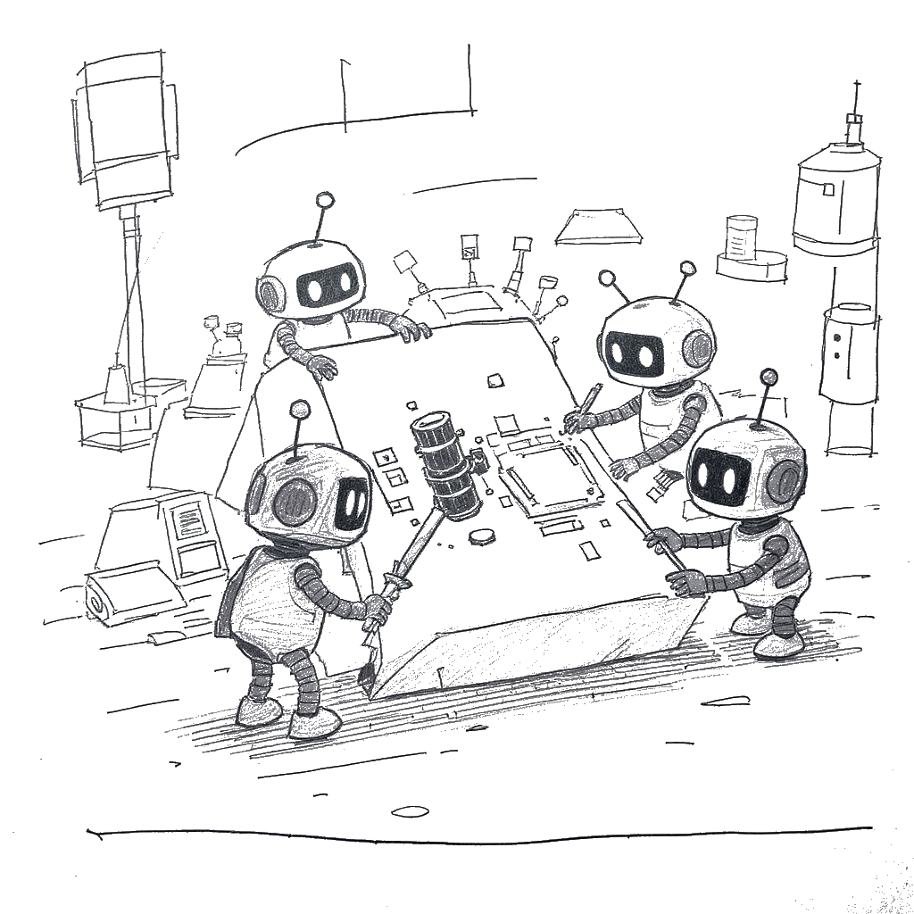

Activity 4 invites you to test how your assessment (or a similar task) behaves when AI is allowed. You first see how well AI can complete the task, then analyse where the response looks like a strong submission and where genuine student thinking or personal context is missing.

From there, you sketch small redesigns—such as adding an in‑class component, requiring an AI use log, or anchoring the task in local or personal examples—to make student judgement more visible while still allowing transparent, limited AI use. For detailed prompts and variants, see ‘Activity 4 – Unlocking the Impossible’ and the overview ‘AI in Pedagogical Design and Delivery’.

# Activity 5: Secure, Safe, and Sustainable AI

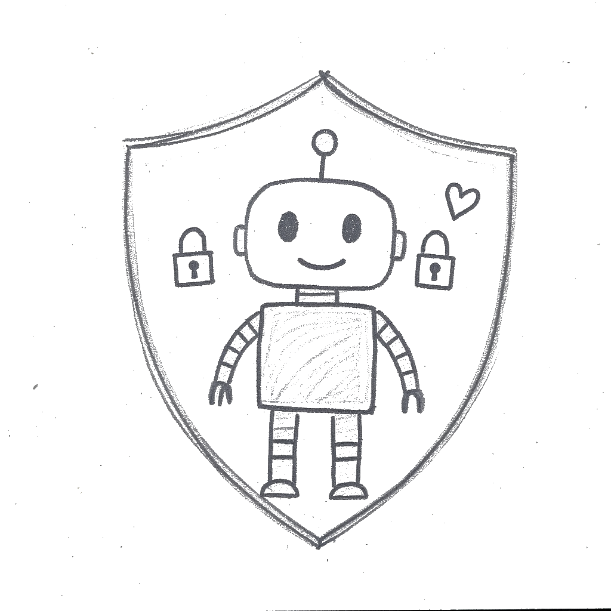

Activity 5 is about choosing one small, concrete next step for secure, safe and sustainable AI use in your own context. You might draft a short guideline for AI use in your unit or team, run a quick risk–benefit check on one planned AI use, or write a Week 1 statement you could say to students or colleagues.

The emphasis is on clear expectations, transparency, and keeping human judgement central, rather than banning AI or outsourcing decisions to tools like Copilot or Turnitin Clarity. For example prompts and micro‑tasks that you can adapt after the workshop, see ‘Activity 5 – Secure, Safe, and Sustainable AI’, ‘Ethics, Data Governance & Integrity’, and ‘Using AI in Education: Roles for Teaching & Research’. For framing broader AI risk, Black Swans and Grey Swans, see ‘Black & Grey Swans in AI’.

# Wrap-Up & Next Steps

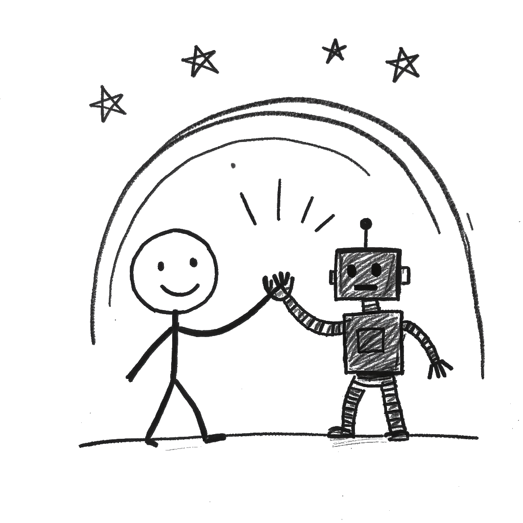

Recap the journey very briefly: “We started by seeing how AI can automate tedious tasks and draft first versions for us. We then worked on designing better prompts, critiquing AI outputs, and finally stress‑testing our assessments and thinking about safe, sustainable use.”

Tie back to Assessment 2030 and your stance: “All of that sits inside the Assessment 2030 idea: we’re not trying to ban AI, and we’re not blindly embracing it. We’re redesigning assessment and teaching so that student judgement, process, and human skills are what really matter.”

Reinforce the human edge: “As more routine writing and summarising gets automated, the value of what only we can do – empathy, feedback, facilitation, contextual judgement – actually goes up. AI is the infrastructure; our job is to design how it supports learning, not replaces it.”

Point to next steps and resources: “If you want to keep experimenting, the companion website has the handouts, prompt frameworks, and references we’ve touched on today. You can pick one activity and try it in a small way in your own unit or team.”

Pause for questions (no dedicated Q&A slide): “I’ll pause here – what questions, worries, or ideas are bubbling up for you? They can be about the tools, the activities, or how this fits with Assessment 2030 in your own context.”

“If things come to you later, feel free to grab me in the corridor, drop me a message, or send through a sample assessment you’d like to stress‑test. I’m very happy to keep working on this with you.”

# Key Sources & Slides (Optional)

| Reference (short) | Main slide(s) / themes |
| --- | --- |
| Bloom (1984) – 2 Sigma Problem | Welcome & AI Landscape (1‑to‑1 tutoring vs classroom; what we’re trying to approximate). |
| Sal Khan TED (2023) – *How AI Could Save (Not Destroy) Education* | Welcome (idea of AI tutor for every student, AI assistant for every teacher). |
| Noroozi et al. (2025) | Practitioner (human agency, real‑time intervention); Challenges & Limitations; Evolving Role of the Educator. |
| Pireci Sejdiu & Sejdiu (2025) | Architect & Practitioner (quiet transformation of HE); Evolving Role of the Educator. |
| Park University (2025) | Intelligent Tutoring Systems (overview of ITS and benefits). |
| Li et al. (2025); Budiman et al. (2025); Kwak (2025); Chen (2025) | ITS & Practitioner slides (evidence that AI‑mediated teaching can improve outcomes). |
| Rojas (2025) | Architect slide (instructional design in the AI era); Evolving Role of the Educator. |
| Dwivedi et al. (2023) | Challenges & Limitations (opportunities vs misuse, integrity, policy gaps). |
| Gerlich (2025); Kosmyna et al. (2025) | Challenges & Activity 3 (cognitive offloading / cognitive debt in AI‑assisted work). |
| Yin et al. (2025); EDUCAUSE (2025); TEQSA (2025); Russell Group (2023) | Challenges & Activity 5 (fairness, bias, ethics, institutional guidelines and guardrails). |

This slide links key readings to the main ideas in the workshop (for example Bloom’s work on tutoring, research on intelligent tutoring systems, and recent studies on AI in higher education, integrity and ethics).

If you want to explore the evidence base or cite work in your own teaching or research, see the ‘References’ document and the overview ‘AI in Pedagogical Design and Delivery’.